# HUDK4050 HW6-Kmeans Clustering & Principal Component Analysis

Xiyun Zhang

12/12/2020

Data: x: Back and Forth y: Up and Down z: Left and Right Acceleration: Acceleration during the activity

Survey Questions: Name: Name who participates in the activity Gender: The person’s gender: female or Male Height: Personal Height in cm Weight: Personal Weight in kg Fitness: Overall fitness level on a scale of 1- 5: 1. Poor 2. Fair 3. Good 4. Very good 5. Excellent. Favor: How much the person prefer jumping: 1 being do not like and 5 being like it very much. Prior: If the person has prior experience of jumping rope or not: 1 being do not have much experience and 5 being have a lot of experience. Illness: Level of illness that might effect the person during jumping rope: 0 being have no illness and 5 being strongly effect by the illness. Happyness: Level of happiness before the person jumping rope: 1 being very sad and 5 being really happy. time_interval: The time when the person did the activity: Morning (6 am - 12pm), Afternoon (12pm - 4pm), Evening (4 pm - 10 pm), Night (10 pm - 6 am). last_meal: How long before jumping rope did the person have his/her last meal: 30mins-1 hour ago, 1 hour- 2 hours ago, more than 2 hours num_jumps: Number of jumps the person accomplished in 1-minute.

```r
library(dplyr)
```

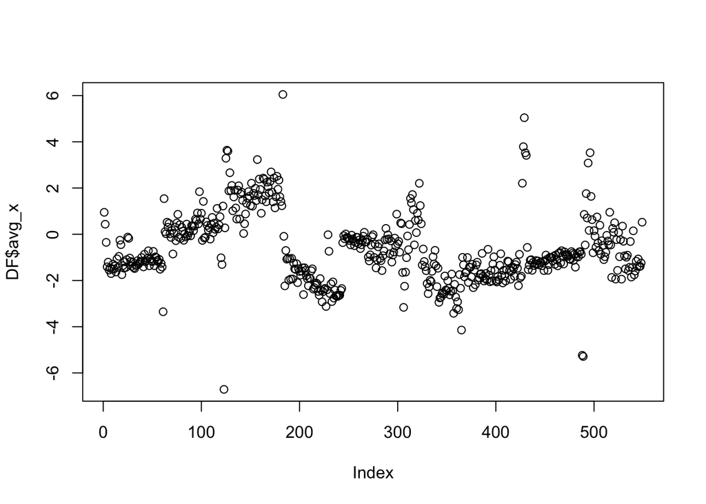

```r
DF <- read.csv("Clean_data_H5.csv")
plot(DF$avg_x)
```

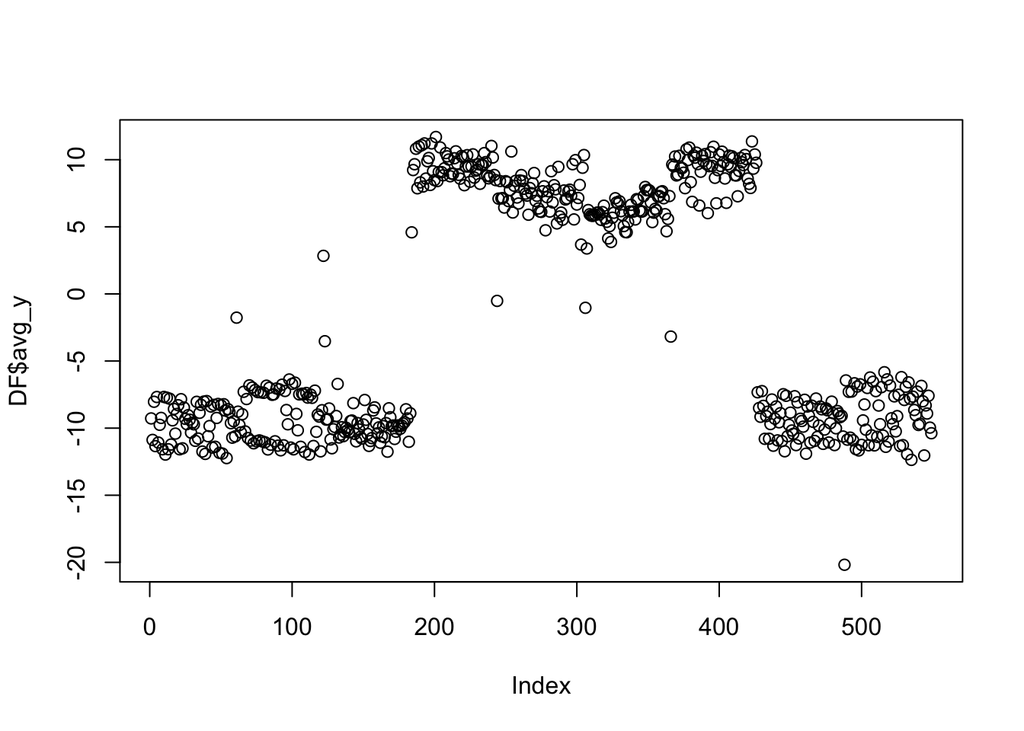

```r
plot(DF$avg_y)
```

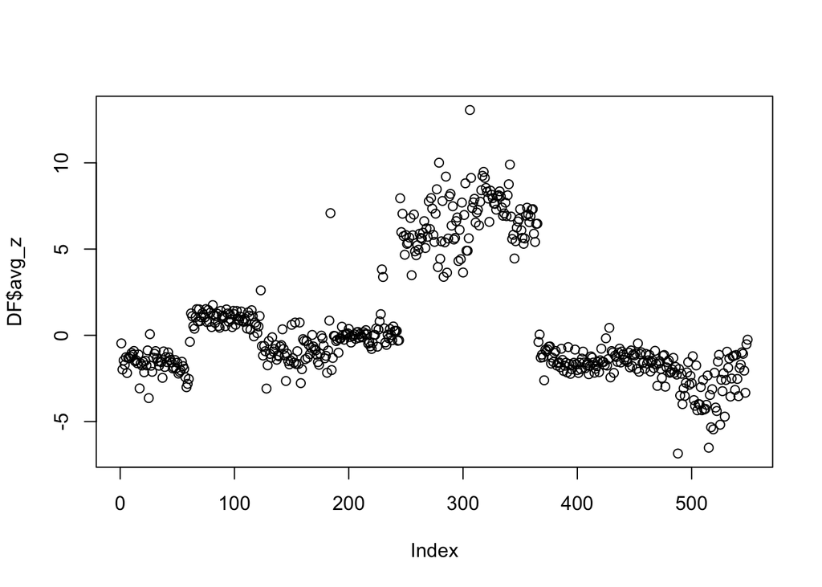

```r
plot(DF$avg_z)
```

```r
for(i in 1:nrow(DF)){
  if(DF$avg_z[i]>2.5){
    DF$avg_z[i] = DF$avg_z[i]-8
  }
}
DF$avg_y = abs(DF$avg_y)
DF = DF[,-1]
DF$Participant[DF$Participant=="Vidya Madhaban"] = "Vidya Madhavan"
DF = mutate(DF,gender = 1, height = 1, weight = 1, fitness = 1, favor = 1, prior = 1, illness = 1, happyness = 1, time_interval = 1, last_meal = 1, num_jumps = 1)
names(DF)[1] = "name"
```

Since there were some negative values in the initial clean data, the plots seemingly to be inefficient to produce any visualization at this point. Therefore, we decided to use the absolute value of these negtive ones to plot new diagrams.

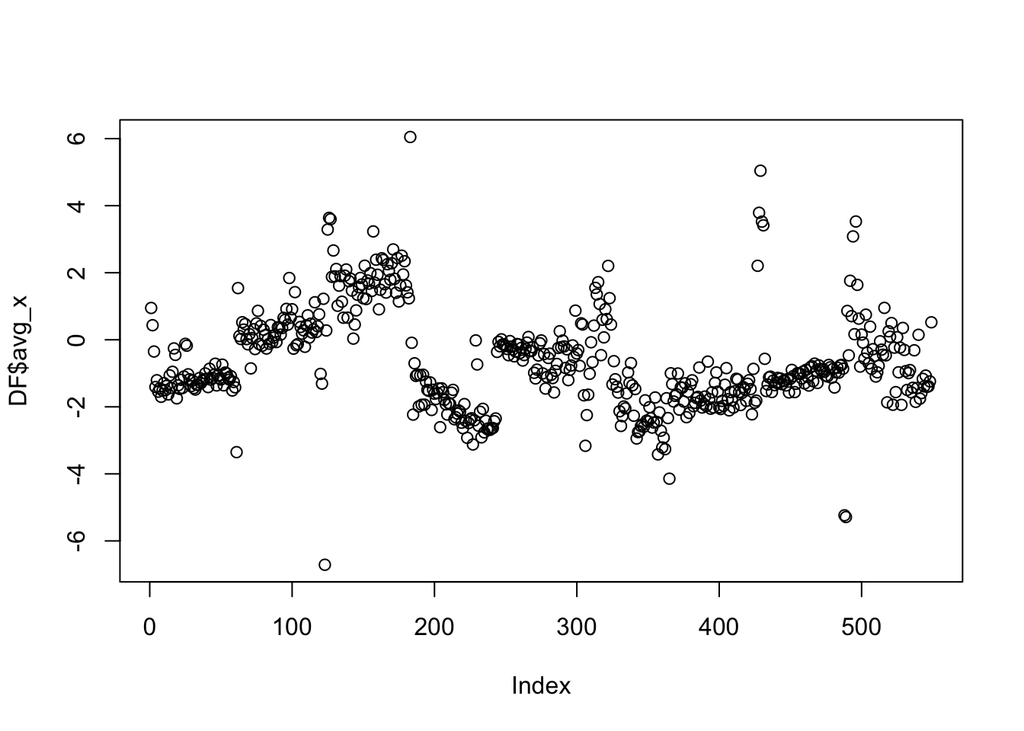

```r
plot(DF$avg_x)
```

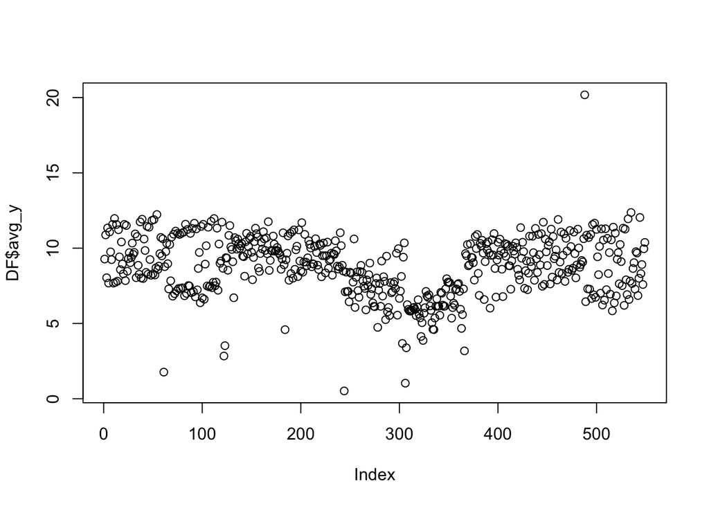

```r
plot(DF$avg_y)
```

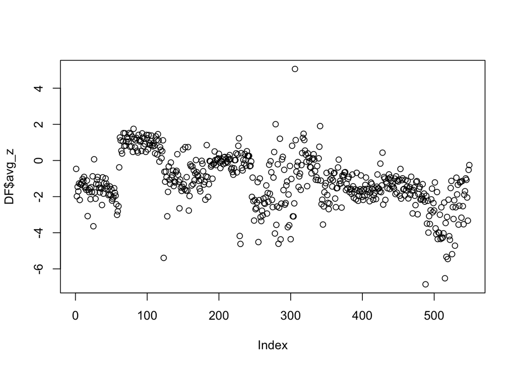

```r
plot(DF$avg_z)
```

It turns out that the plot of y variable to be much more efficient after using the absolute value. Based on the plots, we can tell that most of our data tend to be together with some outliers.

```r
survey = read.csv("Jump Rope Research.csv")
survey1 = select(survey, name = Q1, gender = Q2, height = Q3, weight = Q4, fitness = Q5, favor = Q6, prior = Q7, illness = Q8, happyness = Q9, time_interval = Q10, last_meal = Q11, num_jumps = Q12)
survey1 = survey1[-c(1,2),]
```

```r
colname = colnames(DF)
colname = colname[-c(1:6)]
for(j in colname){
  for(i in 1:nrow(DF)){
    DF[[j]][i] = survey1[[j]][survey1$name == DF$name[i]]
  }
}
colname = c(7,10:16)
for(i in colname){DF[,i] = as.factor(DF[,i])}
colname1 = c(8,9,17)
for(i in colname1){DF[,i] = as.numeric(DF[,i])}
```

```r
DF = mutate(DF, time = rep(0:60,9))
```

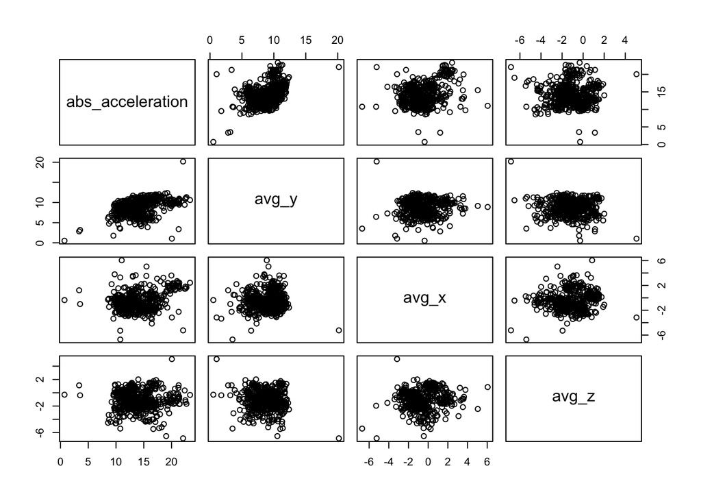

```r
DF1 = select(DF, abs_acceleration,avg_y,avg_x,avg_z)
pairs(DF1)
```

In this plot, we will mainly focused on the regression between acceleration and xyz variables to see whether there is any relationship between acceleration and the predictor variables. From the plot, we can see that it is hardly to tell if there is any relationship between acceleration and the xyz variables that all the plots are in a cloud shape.

```r
cor(DF1)
```

```
##                  abs_acceleration       avg_y      avg_x        avg_z
## abs_acceleration      1.000000000  0.43044889 0.26456843 -0.009613775
## avg_y                 0.430448894  1.00000000 0.05152961 -0.119315015
## avg_x                 0.264568434  0.05152961 1.00000000  0.106860542
## avg_z                -0.009613775 -0.11931501 0.10686054  1.000000000
```

The absolute value of correlation between acceleration and y is: 0.43044889 which stands for a moderate correlation. The absolute value of correlation between acceleration and x is: 0.26456843 which shows a relatively weak correlation. The absolute value of correlation between acceleration and z is: 0.009613775 which means that there is weak or no correlation between these two variables.

### K-means analysis

```r
#install.packages("stats")
#install.packages("dplyr")
#install.packages("ggplot2")
#install.packages("ggfortify")

library(stats)
library(dplyr)
library(ggplot2)
library(ggfortify)
str(DF)
```

```
## 'data.frame':    549 obs. of  18 variables:
##  $ name            : chr  "Hangshi Jin" "Hangshi Jin" "Hangshi Jin" "Hangshi Jin" ...
##  $ time_formated   : chr  "19:00:00" "19:00:01" "19:00:02" "19:00:03" ...
##  $ avg_x           : num  0.949 0.434 -0.35 -1.409 -1.207 ...
##  $ avg_y           : num  9.28 10.88 8.03 11.34 7.68 ...
##  $ avg_z           : num  -0.466 -1.982 -1.458 -1.711 -1.273 ...
##  $ abs_acceleration: num  9.61 15.72 11.79 15.02 12 ...
##  $ gender          : Factor w/ 2 levels "Female","Male": 2 2 2 2 2 2 2 2 2 2 ...
##  $ height          : num  176 176 176 176 176 176 176 176 176 176 ...
##  $ weight          : num  71 71 71 71 71 71 71 71 71 71 ...
##  $ fitness         : Factor w/ 2 levels "2","3": 1 1 1 1 1 1 1 1 1 1 ...
##  $ favor           : Factor w/ 4 levels "1","2","3","4": 2 2 2 2 2 2 2 2 2 2 ...
##  $ prior           : Factor w/ 5 levels "1","2","3","4",..: 2 2 2 2 2 2 2 2 2 2 ...
##  $ illness         : Factor w/ 3 levels "1","2","3": 2 2 2 2 2 2 2 2 2 2 ...
##  $ happyness       : Factor w/ 3 levels "2","3","4": 2 2 2 2 2 2 2 2 2 2 ...
##  $ time_interval   : Factor w/ 4 levels "Afternoon  (12pm - 4pm)",..: 2 2 2 2 2 2 2 2 2 2 ...
##  $ last_meal       : Factor w/ 3 levels "1 hour- 2 hours ago",..: 3 3 3 3 3 3 3 3 3 3 ...
##  $ num_jumps       : num  170 170 170 170 170 170 170 170 170 170 ...
##  $ time            : int  0 1 2 3 4 5 6 7 8 9 ...
```

```r
DF2 <- select(DF,c(1,3:6,8:14,17))
str(DF2)
```

```
## 'data.frame':    549 obs. of  13 variables:
##  $ name            : chr  "Hangshi Jin" "Hangshi Jin" "Hangshi Jin" "Hangshi Jin" ...
##  $ avg_x           : num  0.949 0.434 -0.35 -1.409 -1.207 ...
##  $ avg_y           : num  9.28 10.88 8.03 11.34 7.68 ...
##  $ avg_z           : num  -0.466 -1.982 -1.458 -1.711 -1.273 ...
##  $ abs_acceleration: num  9.61 15.72 11.79 15.02 12 ...
##  $ height          : num  176 176 176 176 176 176 176 176 176 176 ...
##  $ weight          : num  71 71 71 71 71 71 71 71 71 71 ...
##  $ fitness         : Factor w/ 2 levels "2","3": 1 1 1 1 1 1 1 1 1 1 ...
##  $ favor           : Factor w/ 4 levels "1","2","3","4": 2 2 2 2 2 2 2 2 2 2 ...
##  $ prior           : Factor w/ 5 levels "1","2","3","4",..: 2 2 2 2 2 2 2 2 2 2 ...
##  $ illness         : Factor w/ 3 levels "1","2","3": 2 2 2 2 2 2 2 2 2 2 ...
##  $ happyness       : Factor w/ 3 levels "2","3","4": 2 2 2 2 2 2 2 2 2 2 ...
##  $ num_jumps       : num  170 170 170 170 170 170 170 170 170 170 ...
```

```r
colname = c(8:12)
for(i in colname){DF2[,i] = as.numeric(levels(DF2[,i]))[DF2[,i]]}
str(DF2)
```

```
## 'data.frame':    549 obs. of  13 variables:
##  $ name            : chr  "Hangshi Jin" "Hangshi Jin" "Hangshi Jin" "Hangshi Jin" ...
##  $ avg_x           : num  0.949 0.434 -0.35 -1.409 -1.207 ...
##  $ avg_y           : num  9.28 10.88 8.03 11.34 7.68 ...
##  $ avg_z           : num  -0.466 -1.982 -1.458 -1.711 -1.273 ...
##  $ abs_acceleration: num  9.61 15.72 11.79 15.02 12 ...
##  $ height          : num  176 176 176 176 176 176 176 176 176 176 ...
##  $ weight          : num  71 71 71 71 71 71 71 71 71 71 ...
##  $ fitness         : num  2 2 2 2 2 2 2 2 2 2 ...
##  $ favor           : num  2 2 2 2 2 2 2 2 2 2 ...
##  $ prior           : num  2 2 2 2 2 2 2 2 2 2 ...
##  $ illness         : num  2 2 2 2 2 2 2 2 2 2 ...
##  $ happyness       : num  3 3 3 3 3 3 3 3 3 3 ...
##  $ num_jumps       : num  170 170 170 170 170 170 170 170 170 170 ...
```

```r
DF2 <- DF2 %>% group_by(name)%>%summarise(avg_x=mean(avg_x), avg_y=mean(avg_y),avg_z=mean(avg_z),abs_acceleration=mean(abs_acceleration),height = mean(height), weight = mean(weight), fitness = mean(fitness), favor = mean(favor), prior = mean(prior), illness = mean(illness), happyness = mean(happyness),  num_jumps = mean(num_jumps))
DF_kmeans <- scale(DF2[,-1])
```

```r
#install.packages("factoextra")
library(factoextra)
```

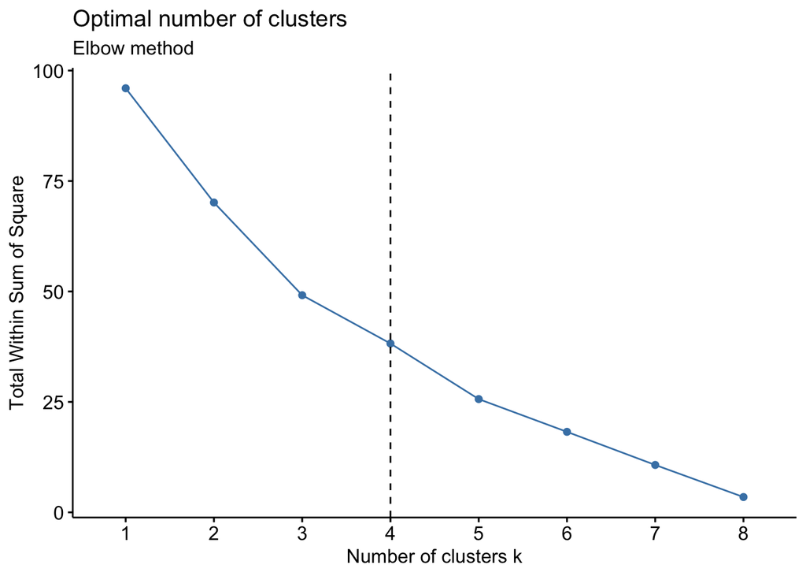

```r
fviz_nbclust(DF_kmeans, kmeans, method = "wss",k.max=8) +
  geom_vline(xintercept = 4, linetype = 2)+
  labs(subtitle = "Elbow method")
```

The Optimal Numbers of Cluster indicates that we should use k = 4 for further analysis.

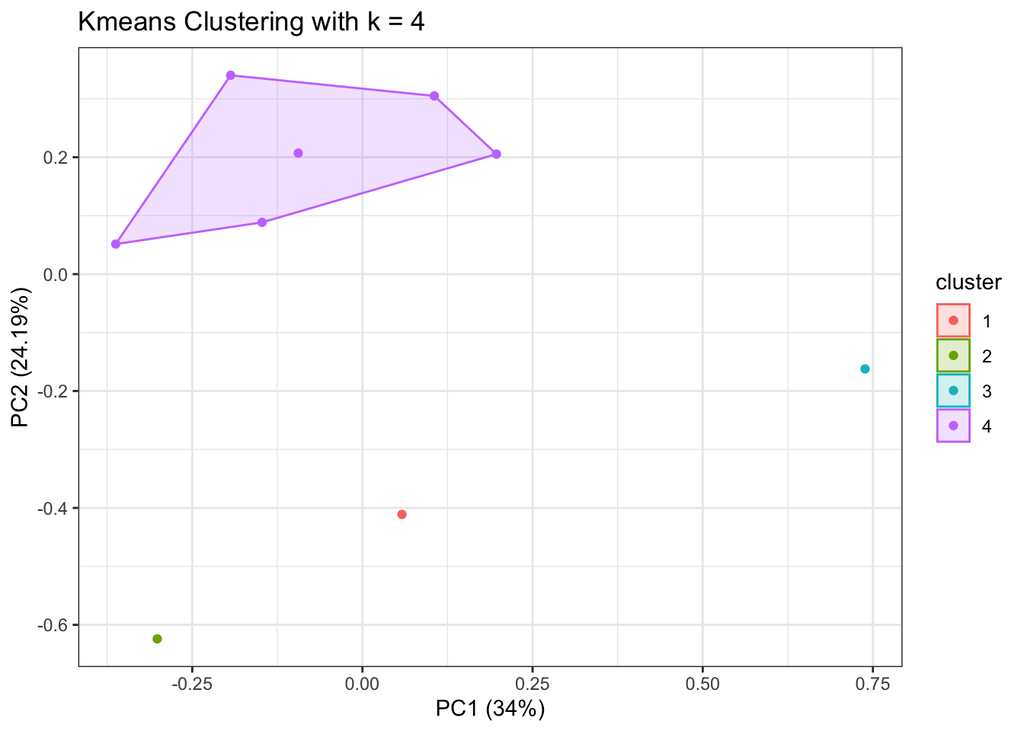

```r
# Compute k-means with k = 4
set.seed(8)
km4 <- kmeans(DF_kmeans, 4)
autoplot(km4,DF_kmeans,frame=T)+
  labs(title = "Kmeans Clustering with k = 4")+
  theme_bw()
```

Although the optimal numbers of clusters indicates we should have 4 clusters, the above plot doesn’t give us as useful insights as we thought. It is hardly to separte our group member into two groups: novices and experts. So, we try to use 2-clusters instead.

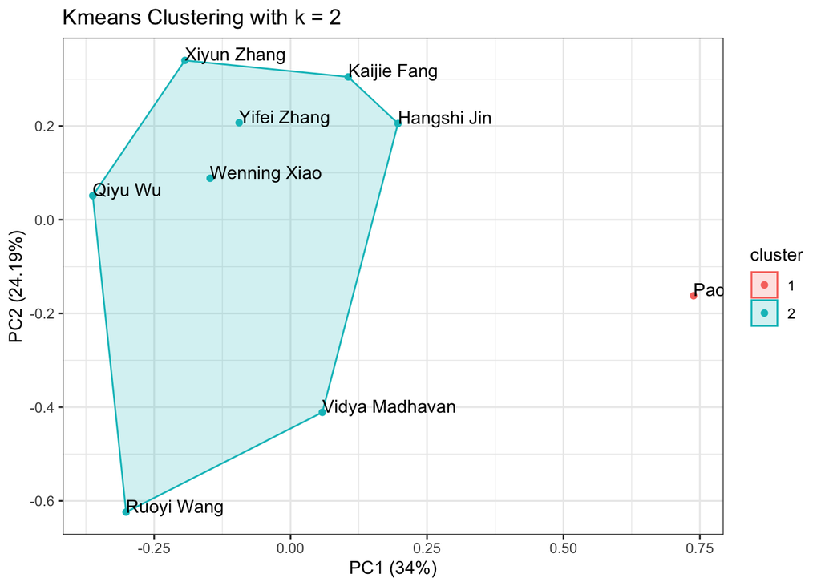

```r
# Compute k-means with k = 2
set.seed(6)
km2 <- kmeans(DF_kmeans, 2)
autoplot(km2,DF_kmeans,frame=T) +
  geom_text(aes(label=DF2$name),hjust=0, vjust=0)+
  labs(title = "Kmeans Clustering with k = 2")+
  theme_bw()
```

```r
print(km2)
```

```
## K-means clustering with 2 clusters of sizes 1, 8
##
## Cluster means:
##        avg_x      avg_y       avg_z abs_acceleration    height     weight
## 1  2.1196019  0.8138908  0.11850311        1.9790620  1.386280  1.8138785
## 2 -0.2649502 -0.1017363 -0.01481289       -0.2473828 -0.173285 -0.2267348
##      fitness      favor      prior    illness happyness  num_jumps
## 1  0.8432740 -1.5343905 -1.7071584 -0.9428090         0 -1.3502367
## 2 -0.1054093  0.1917988  0.2133948  0.1178511         0  0.1687796
##
## Clustering vector:
## [1] 2 2 1 2 2 2 2 2 2
##
## Within cluster sum of squares by cluster:
## [1]  0.00000 70.13662
##  (between_SS / total_SS =  26.9 %)
##
## Available components:
##
## [1] "cluster"      "centers"      "totss"        "withinss"     "tot.withinss"
## [6] "betweenss"    "size"         "iter"         "ifault"
```

```r
DF2 <- data.frame(DF2, km2$cluster)
```

We call Group 1 with smaller number of rope jumping and less prior experience Novice while Group 2 with higher number of rope jumping and more prior experience Experienced.

### Principal Component Analysis

```r
pca <- prcomp(DF_kmeans, scale. = TRUE)
summary(pca)
```

```
## Importance of components:
##                         PC1    PC2    PC3    PC4     PC5     PC6     PC7
## Standard deviation     2.02 1.7039 1.3390 1.1283 1.03879 0.68280 0.54689
## Proportion of Variance 0.34 0.2419 0.1494 0.1061 0.08992 0.03885 0.02492
## Cumulative Proportion  0.34 0.5819 0.7313 0.8374 0.92736 0.96622 0.99114
##                            PC8       PC9
## Standard deviation     0.32606 2.392e-16
## Proportion of Variance 0.00886 0.000e+00
## Cumulative Proportion  1.00000 1.000e+00
```

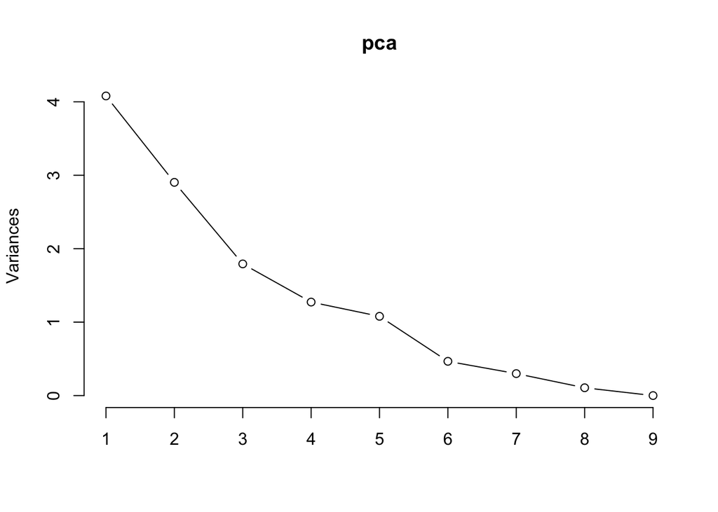

```r
plot(pca, type = "lines")
```

```r
(loadings <- abs(pca$rotation))
```

```
##                         PC1        PC2        PC3         PC4        PC5
## avg_x            0.37542580 0.03628051 0.24576930 0.343665683 0.11229841
## avg_y            0.10603774 0.42667501 0.38495551 0.169102849 0.05687983
## avg_z            0.07691425 0.06361843 0.29949535 0.005274036 0.86003475
## abs_acceleration 0.45629833 0.05307350 0.06374263 0.044290147 0.26399670
## height           0.43226507 0.23396274 0.11868546 0.166704537 0.10642150
## weight           0.47486405 0.05383270 0.09144776 0.161819915 0.11871398
## fitness          0.01353252 0.39205328 0.17265215 0.514297501 0.22250314
## favor            0.21339597 0.34173130 0.42711132 0.129836403 0.24925160
## prior            0.35916099 0.29235587 0.03604691 0.311830596 0.09151626
## illness          0.18082309 0.31905162 0.29217340 0.541309996 0.11148995
## happyness        0.09346788 0.33068504 0.56331481 0.083549327 0.03908439
## num_jumps        0.07202587 0.43014765 0.24284993 0.344583619 0.12415457
##                         PC6         PC7        PC8        PC9
## avg_x            0.30441505 0.571090168 0.27642151 0.33131053
## avg_y            0.31802799 0.477264783 0.21009371 0.24138678
## avg_z            0.05118762 0.023554434 0.18679415 0.09070236
## abs_acceleration 0.27655285 0.232972361 0.22675340 0.39805892
## height           0.07412206 0.009834898 0.17558808 0.17562999
## weight           0.04367159 0.110861803 0.18078541 0.21629557
## fitness          0.45864103 0.173044903 0.14907909 0.03322864
## favor            0.30152618 0.002927944 0.40213853 0.53265575
## prior            0.40000835 0.079816139 0.36134646 0.49864657
## illness          0.24621230 0.104098452 0.02242748 0.12547806
## happyness        0.05287082 0.294404772 0.61473616 0.15560821
## num_jumps        0.44158194 0.494996934 0.19160715 0.11926829
```

```r
#biplot(pca)
```

It can be seen from the summary that PC1 and PC2 contribute to 58.19% of the variation of the data while PC1, PC2, PC3 and PC4 contribute to 83.74% of the variation of the data.

PC1 has comparatively high loading scores for height, weight, abs_acceleration, avg_x and prior. PC2 has comparatively high loading scores for avg_y, fitness, favor, illness, happyness and num_jumps.

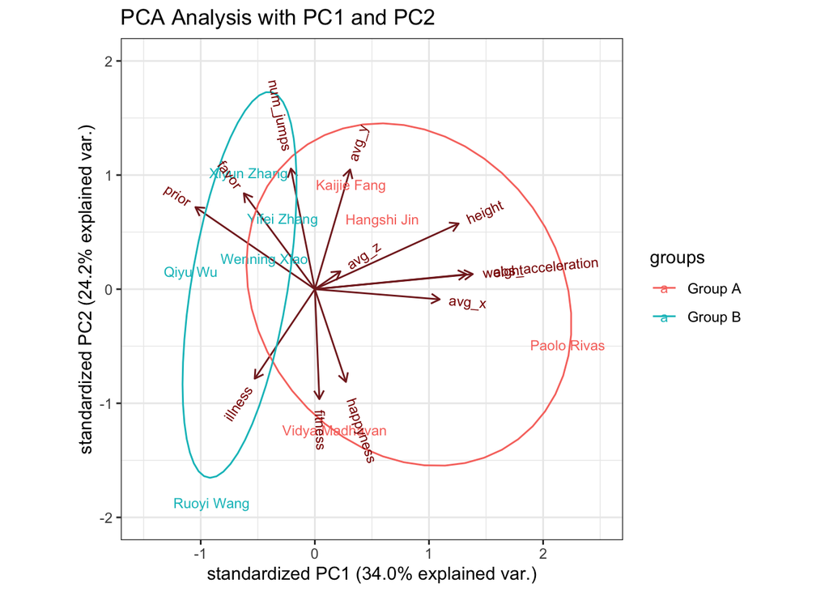

```r
#library(devtools)
#install_github("vqv/ggbiplot")
library(ggbiplot)
#ggbiplot(pca)+ylim(-2,2)+xlim(-2,2.5)
#ggbiplot(pca, labels=DF2$name)+ylim(-2,2)+xlim(-1.5,2.5)

pca_group <- c(rep("Group A", 3), rep("Group B",2), "Group A", rep("Group B",3))

ggbiplot(pca ,ellipse=TRUE, choices = c(1,2),  labels=DF2$name, groups=pca_group)+ylim(-2,2)+xlim(-1.5,2.5)+ labs(title = "PCA Analysis with PC1 and PC2")+ theme_bw()
```

Here, we can see that the variables height, weight, abs_acceleration and avg_x all contribute to PC1, with higher values in those variables moving the samples to the right on this plot.

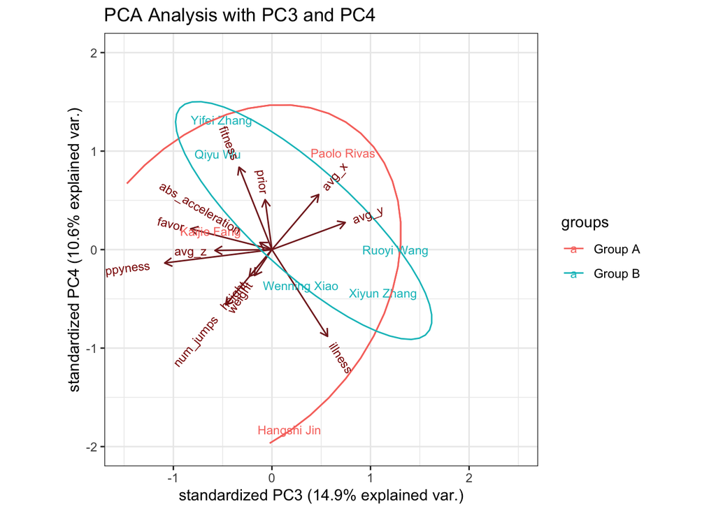

```r
ggbiplot(pca ,ellipse=TRUE, choices = c(3,4), labels=DF2$name, groups=pca_group)+ylim(-2,2)+xlim(-1.5,2.5)+ labs(title = "PCA Analysis with PC3 and PC4")+ theme_bw()
```

We don’t see much insights of Groups with PC3 and PC4 because they overlapped heavily.